# Forbers Highest

## Introduce

Hi, my name is Dhanachote W. I practice writing queries, coding, and analyzing data to ensure I don't forget what I have learned.

By the way, I have many projects. Although they may not be impactful projects because I lack experience in data analysis, I pursue them independently and formulate questions based on the dataset.

This particular project is a mini project for practice, and I obtained the data from [Kaggle.com](https://www.kaggle.com/discussions/general/268890).

Also, I work in **VSCODE** using **Python** language for analysis and **Jupiter notebook** to create this project as a report.

Lastly, I am aware that my project is somewhat basic and that anyone can do it, and I believe someone could do it better than me. However, I am open to receiving recommendations to improve my skills in visualization, analysis, and coding. I welcome the opportunity to learn from your suggestions.

## Data Name

### Forbers Highest Paid Athletes 1990 - 2020

**About Dataset**

**Context**

Here is a completel list of the world's highest-paid athletes since the first list published by Forbes in 1990. In 2002, they changed the reporting period from the full calendar year to June-to-June, and consequently, there are no records for 2001.

**Content**

**Acknowledgments**

The data has been extracted from topendsports.com website

**Data library**

- S.NO: Serial number
- Name: Name of Forbes
- Nationality: Nationality of Forbes
- Current Rank: Current ranking based on earnings each year
- Previous Year Rank: Previous year's rank (may be NULL for some entries)
- Sport: Sport played by Forbes athlete
- Year: Year of earnings
- Earnings ($million): Earnings from sports

## Import library using for analyze the data

I use 3 library for analyze the dataset such as **pandas**, **numpy** and **matplotlib** for create a chart.

Firstly, I import the file data set using by `pd.read_csv` and `.info` to check the columns name and `NULL` in the dataset.

```python
## load lib
import pandas as pd
import numpy as np
import matplotlib.pyplot as plt

## load dataset from csv
data = pd.read_csv("Forbes_Richest_Athletes_1990-2020.csv")
data = pd.DataFrame(data)
data = data.reset_index()
print(data.describe())
print(data.info())
```

```
            index        S.NO  Current Rank         Year  earnings ($ million)
count  301.000000  301.000000    301.000000   301.000000            301.000000
mean   150.000000  151.000000      5.448505  2005.122924             45.516279
std     87.035433   87.035433      2.850995     9.063563             33.525337
min      0.000000    1.000000      1.000000  1990.000000              8.100000
25%     75.000000   76.000000      3.000000  1997.000000             24.000000
50%    150.000000  151.000000      5.000000  2005.000000             39.000000
75%    225.000000  226.000000      8.000000  2013.000000             59.400000
max    300.000000  301.000000     10.000000  2020.000000            300.000000
<class 'pandas.core.frame.DataFrame'>
RangeIndex: 301 entries, 0 to 300
Data columns (total 9 columns):
 #   Column                Non-Null Count  Dtype
---  ------                --------------  -----
 0   index                 301 non-null    int64
 1   S.NO                  301 non-null    int64
 2   Name                  301 non-null    object
 3   Nationality           301 non-null    object
 4   Current Rank          301 non-null    int64
 5   Previous Year Rank    277 non-null    object
 6   Sport                 301 non-null    object
 7   Year                  301 non-null    int64
 8   earnings ($ million)  301 non-null    float64
dtypes: float64(1), int64(4), object(4)
memory usage: 21.3+ KB
None
```

## Rename Column

I found it difficult to type the column name `earnings ($million)` when coding for analysis, so I decided to rename it to `earnings_million`.

```python
data = data.rename(columns={"earnings ($ million)" : "earnings_million"})

data.head()
```

|  | index | S.NO | Name | Nationality | Current Rank | Previous Year Rank | Sport | Year | earnings_million |
| --- | --- | --- | --- | --- | --- | --- | --- | --- | --- |
| 0 | 0 | 1 | Mike Tyson | USA | 1 | NaN | boxing | 1990 | 28.6 |
| 1 | 1 | 2 | Buster Douglas | USA | 2 | NaN | boxing | 1990 | 26.0 |
| 2 | 2 | 3 | Sugar Ray Leonard | USA | 3 | NaN | boxing | 1990 | 13.0 |
| 3 | 3 | 4 | Ayrton Senna | Brazil | 4 | NaN | auto racing | 1990 | 10.0 |
| 4 | 4 | 5 | Alain Prost | France | 5 | NaN | auto racing | 1990 | 9.0 |

## Replace name of sport in Sport column

I found many types of sports that have the same meaning but different words. Therefore, I used `.replace` to standardize them.

```python
data["Sport"].replace({"tennis": "Tennis",
                       "boxing":"Boxing",
                       "auto racing": "Auto Racing",
                       "auto Racing": "Auto Racing",
                       "Auto racing": "Auto Racing",
                       "golf": "Golf",
                       "basketball": "Basketball",
                       "NBA" : "Basketball",
                       "ice hockey": "Ice Hockey",
                       "Hockey": "Ice Hockey",
                       "baseball": "Baseball",
                       "Auto Racing (Nascar)": " NASCAR",
                       "F1 racing": "F1 Motorsports"
                       }, inplace = True)
data = data
data.head()
```

|  | index | S.NO | Name | Nationality | Current Rank | Previous Year Rank | Sport | Year | earnings_million |
| --- | --- | --- | --- | --- | --- | --- | --- | --- | --- |
| 0 | 0 | 1 | Mike Tyson | USA | 1 | NaN | Boxing | 1990 | 28.6 |
| 1 | 1 | 2 | Buster Douglas | USA | 2 | NaN | Boxing | 1990 | 26.0 |
| 2 | 2 | 3 | Sugar Ray Leonard | USA | 3 | NaN | Boxing | 1990 | 13.0 |
| 3 | 3 | 4 | Ayrton Senna | Brazil | 4 | NaN | Auto Racing | 1990 | 10.0 |
| 4 | 4 | 5 | Alain Prost | France | 5 | NaN | Auto Racing | 1990 | 9.0 |

## Top 10 earning all the time

In this topic, I want to analyze the highest earners of all time in sports. I aim to extract data containing only the Name, Sport, and earnings_million to answer this question.

Firstly, I use `.groupby` on the columns Name and Sport and calculate the total earnings from 1990 to 2020 using the aggregation function `.agg(sum)`.

Then, I found that the highest earner is **Tiger Woods**, with earnings of $1,373.8 million.

Lastly, I created a bar chart to clarify and explain the question about the top 10 highest Forbers earners.

```
                                   earnings_million
Name               Sport
Tiger Woods        Golf                      1373.8
LeBron James       Basketball                 844.8
Floyd Mayweather   Boxing                     840.0
Roger Federer      Tennis                     781.1
Cristiano Ronaldo  Soccer                     749.1
Michael Jordan     Basketball                 738.8
Lionel Messi       Soccer                     683.2
Kobe Bryant        Basketball                 601.1
Phil Mickelson     Golf                       519.9
Michael Schumacher F1 Motorsports             516.0
```

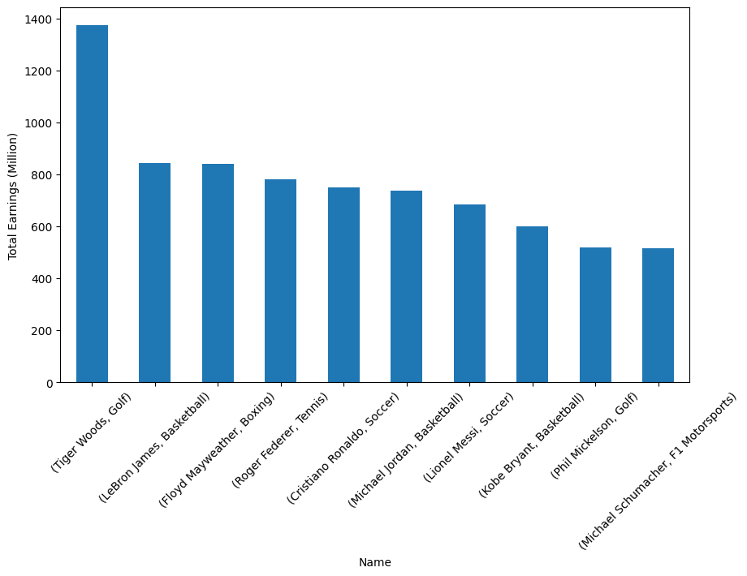

```python
## Top earning from 1990-2020

forbes_hight = data.groupby(["Name","Sport"])["earnings_million"].agg(sum)
forbes_hight_sort = forbes_hight.sort_values(ascending = False)
print(pd.DataFrame(forbes_hight_sort).head(10))
forbes_hight_10 = forbes_hight_sort.head(10)

## create a bar chart

plt.figure(figsize=(10,6))
forbes_hight_10.plot(kind="bar")
plt.xlabel("Name")
plt.ylabel("Total Earnings (Million)")
plt.xticks(rotation=45)
plt.show()
```

## Sport earning since 1990 and 2020

In this section, I aim to determine the earnings from 1990 to 2020 for each sport.

As depicted in the chart, various sports are represented, with Boxing emerging as the highest-earning sport in 1990. This suggests that Boxing was the most popular sport during that year.

By contrast, Soccer dominates in 2020, being the highest-earning sport. This indicates Soccer's widespread popularity in that year.

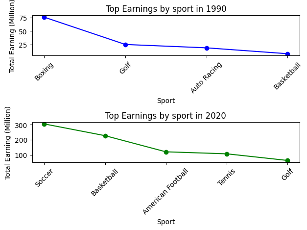

```python
## top earning since 1990 | 2020
earn1990 = data[data["Year"]== 1990][["Name", "Sport", "earnings_million"]].groupby("Sport").sum()
earn1990 = earn1990.sort_values("earnings_million", ascending=False)

earn2020 = data[data["Year"]==2020][["Name", "Sport", "earnings_million"]].groupby("Sport").sum()
earn2020 = earn2020.sort_values("earnings_million", ascending=False)

fig, ax=plt.subplots(2,1)

## 1990
ax[0].plot(earn1990.index, earn1990["earnings_million"], color="b", marker="o")
ax[0].set_title("Top Earnings by sport in 1990")
ax[0].set_xlabel("Sport")
ax[0].set_ylabel("Total Earning (Million)")


## 2020
ax[1].plot(earn2020.index, earn2020["earnings_million"], color="g", marker="o")
ax[1].set_title("Top Earnings by sport in 2020")
ax[1].set_xlabel("Sport")
ax[1].set_ylabel("Total Earning (Million)")

for ax in ax:
    ax.tick_params(axis="x", rotation=45)

plt.tight_layout()
plt.show()
```

## The earning chart of Floyd Mayweather

```
                 Name Nationality  Year  earnings_million
241  Floyd Mayweather         USA  2015             300.0
271  Floyd Mayweather         USA  2018             285.0
231  Floyd Mayweather         USA  2014             105.0
211  Floyd Mayweather         USA  2012              85.0
192  Floyd Mayweather         USA  2010              65.0
```

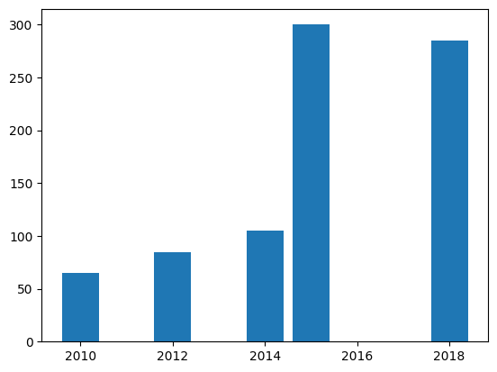

```python
import matplotlib.pyplot as plt

fm = data[data["Name"]== "Floyd Mayweather"].sort_values("earnings_million", ascending=False)
print(fm[["Name", "Nationality", "Year", "earnings_million"]])

fig, ax=plt.subplots()
ax.bar(fm["Year"], fm["earnings_million"])
plt.show()
```

## Sport Category

Even though Tiger Woods is the highest-earning Forbes athlete in the sport of Golf, the total earnings for Golf from 1990 to 2020 do not rank it as the highest-earning sport.

If you observe the bar chart, you'll notice that Basketball holds the highest earnings among all sports, with Golf ranking third.

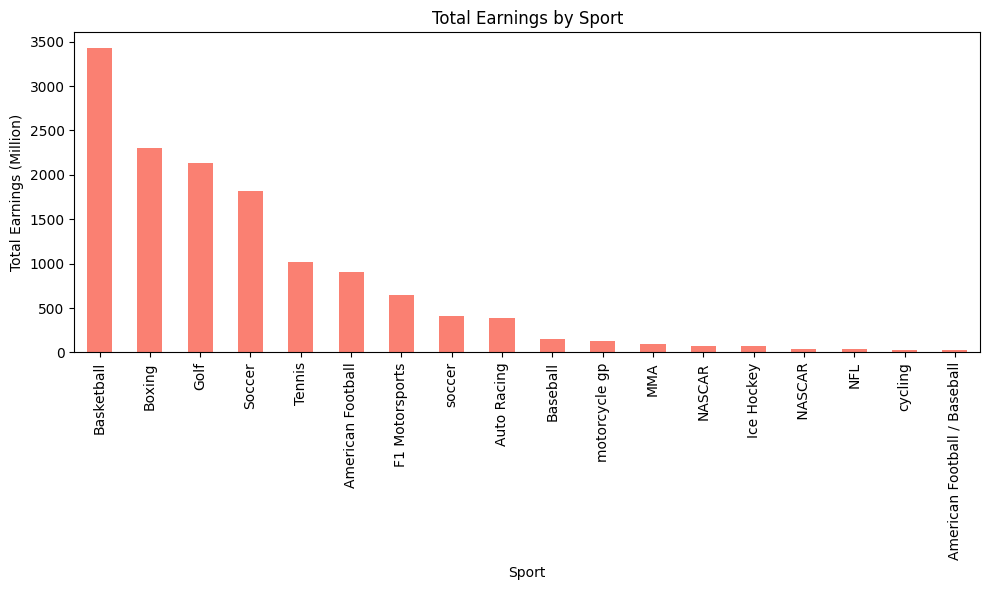

```python
# Grouping data by sport and summing earnings
sport_earning = data.groupby("Sport")["earnings_million"].agg(sum)

# Sorting values in ascending order
sport_earning_sort = sport_earning.sort_values(ascending=False)

# create the bar chart
plt.figure(figsize=(10,6))
sport_earning_sort.plot(kind="bar",
                        color="salmon")
plt.xlabel("Sport")
plt.ylabel("Total Earnings (Million)")
plt.title("Total Earnings by Sport")
plt.xticks(rotation=90)
plt.tight_layout()
plt.show()
```

## For the Last Part

I am coding data within this scope to identify who earned the most between the years 2018 and 2020. After analyzing the data for 2018, it was found that the highest earner was **Floyd Mayweather**, in the sport of boxing.

However, upon directly examining the data, it becomes apparent that the total earnings from soccer surpass those from boxing because, in that year, Forbes reported higher earnings in soccer. Moreover, soccer sports continue to outperform even in 2020, with total earnings matching those of 2018.

```python
## Total earning sport in 2018 : 2020
    ## 2018
earn2018 = data[data["Year"]== 2018][["Name", "Sport",  "earnings_million"]].groupby("Name").sum()
earn2018 = earn2018.sort_values("earnings_million", ascending=False)
print(earn2018.head(10))
count_2018 = earn2018.groupby(["Sport"]).size().sort_values(ascending=False)
count_2018 = pd.DataFrame(count_2018)





    ## 2020
earn2020 = data[data["Year"]== 2020][["Name", "Sport", "earnings_million"]].groupby("Name").sum()
earn2020 = earn2020.sort_values("earnings_million", ascending=False)
print(earn2020.head(10))
count_2020 = earn2020.groupby(["Sport"]).size().sort_values(ascending=False)
count_2020 = pd.DataFrame(count_2020)
```

```
                               Sport  earnings_million
Name
Floyd Mayweather              Boxing             285.0
Lionel Messi                  Soccer             111.0
Cristiano Ronaldo             Soccer             108.0
Conor McGregor                   MMA              99.0
Neymar                        Soccer              90.0
LeBron James              Basketball              85.5
Roger Federer                 Tennis              77.2
Stephen Curry             Basketball              76.9
Matt Ryan          American Football              67.3
Matthew Stafford   American Football              59.5
                               Sport  earnings_million
Name
Roger Federer                 Tennis             106.3
Cristiano Ronaldo             Soccer             105.0
Lionel Messi                  Soccer             104.0
Neymar                        Soccer              95.5
LeBron James              Basketball              88.2
Stephen Curry             Basketball              74.4
Kevin Durant              Basketball              63.9
Tiger Woods                     Golf              62.3
Kirk Cousins       American Football              60.5
Carson Wentz       American Football              59.1
```

```python
##
count_2018, count_2020
```

```
(                   0
 Sport
 Soccer             3
 American Football  2
 Basketball         2
 Boxing             1
 MMA                1
 Tennis             1,
                    0
 Sport
 Basketball         3
 Soccer             3
 American Football  2
 Golf               1
 Tennis             1)
```